# CMPS3160_Project-2 copy

**CMPS3160 Project: Delays & Declines**

Happy Herold, Syed Mehran

[Github Page](https://syedmehran.github.io/cmps3160-project/)

**Project Goals:**

> Authors hope to learn about how operational inefficiency contributes to stock prices.

> Authors would also like to learn how soon the market responds to inefficiencies

> Authors want to investigate how one could use this data to develop a model that can predict price shifts due to inefficiency

**Milestone 1:**

**Data Set Websites:**

[Marketing Carrier On-Time Performance Data](https://www.transtats.bts.gov/Fields.asp?gnoyr_VQ=FGK)

[Yahoo Finance](https://finance.yahoo.com/)

**Collaboration Plan:**

A private project git repository has been created to store the data and the Colab Jupyter notebook. Authors intend to meet once a week to discuss weekly project goals, raise questions, and develop the final product. Meetings will take place by Zoom or in-person and the pair will communicate using text messaging. The weekly goals and project to-do list are shared in a OneNote document that is shared between the pair. Up until Milestone 2 the authors will continue to calculate various airline performance metrics from the flight data and begin predicting the stock prices based on these metrics with different scikit-learn regression models. After completing Milestone 2, the authors plan on gathering data visualizations and the model to develop a final website and presentation that clearly explains the aim of the project, the steps and tools utilized in the project, and the findings from the analysis and model created.

```python
!git clone https://github.com/syedmehran/cmps3160-project.git
%cd cmps3160-project/
```

```
fatal: destination path 'cmps3160-project' already exists and is not an empty directory.
/Users/happyherold/Desktop/cmps3160-project
```

```python
#pip install yfinance
```

```python
import numpy as np
import pandas as pd
import matplotlib.pyplot as plt
import glob
import yfinance as yf
import datetime
```

# Stock data ETL

```python
#Load stock data in

financ_UAL = yf.download('UAL', start = '2015-04-30') # united
financ_ALK = yf.download('ALK', start = '2015-04-30') # alaskan
financ_AAL = yf.download("AAL", start = '2015-04-30') # american
financ_ALGT = yf.download("ALGT", start = '2015-04-30') # allegiant
financ_HA = yf.download("HA", start = '2015-04-30') # hawaiian
financ_LUV = yf.download("LUV", start = '2015-04-30') # southwest
financ_SAVE = yf.download("SAVE", start = '2015-04-30') # spirit
financ_JBLU = yf.download("JBLU", start = '2015-04-30') # jetblue
financ_DAL = yf.download("DAL", start = '2015-04-30') # delta
financ_JETS = yf.download("JETS", start = '2015-04-30') # JETS etf index
financ_OIL = yf.download('CL=F', start = '2015-04-30') # united

financ_airlines = {
    'United': financ_UAL,
    'Alaskan': financ_ALK,
    'American': financ_AAL,
    'Allegiant': financ_ALGT,
    'JetBlue': financ_JBLU,
    'Hawaiian': financ_HA,
    'Southwest': financ_LUV,
    'Spirit': financ_SAVE,
    'Delta': financ_DAL,
    'JETS' : financ_JETS,
    'Crude Oil' : financ_OIL
}

airline_colors = {
    'United': '#1f77b4',  # muted blue
    'Alaskan': '#2ca02c',  # cooked asparagus green
    'American': '#d62728',  # brick red
    'Allegiant': '#ff7f0e',  # safety orange
    'JetBlue': '#9467bd',  # muted purple
    'Hawaiian': '#e377c2',  # raspberry yogurt pink
    'Southwest': '#7f7f7f',  # middle gray
    'Spirit': '#bcbd22',  # curry yellow-green
    'Delta': '#17becf',  # blue-teal
    'JETS': '#8c564b',  # chestnut brown
    'Crude Oil': '#c7c7c7'  # silver gray
}
```

```
[*********************100%%**********************]  1 of 1 completed
[*********************100%%**********************]  1 of 1 completed
[*********************100%%**********************]  1 of 1 completed
[*********************100%%**********************]  1 of 1 completed
[*********************100%%**********************]  1 of 1 completed
[*********************100%%**********************]  1 of 1 completed
[*********************100%%**********************]  1 of 1 completed
[*********************100%%**********************]  1 of 1 completed
[*********************100%%**********************]  1 of 1 completed
[*********************100%%**********************]  1 of 1 completed
[*********************100%%**********************]  1 of 1 completed
```

```python
for airline, df in financ_airlines.items():
    print(f"{airline} DataFrame size: {df.shape}")
    print(f"Null values in {airline}:")
    null_counts = df.isnull().sum()  # counts of null values in each column
    print(null_counts[null_counts > 0])  # print columns with null values
    print("\n")
```

```
United DataFrame size: (2155, 6)
Null values in United:
Series([], dtype: int64)


Alaskan DataFrame size: (2155, 6)
Null values in Alaskan:
Series([], dtype: int64)


American DataFrame size: (2155, 6)
Null values in American:
Series([], dtype: int64)


Allegiant DataFrame size: (2155, 6)
Null values in Allegiant:
Series([], dtype: int64)


JetBlue DataFrame size: (2155, 6)
Null values in JetBlue:
Series([], dtype: int64)


Hawaiian DataFrame size: (2155, 6)
Null values in Hawaiian:
Series([], dtype: int64)


Southwest DataFrame size: (2155, 6)
Null values in Southwest:
Series([], dtype: int64)


Spirit DataFrame size: (2155, 6)
Null values in Spirit:
Series([], dtype: int64)


Delta DataFrame size: (2155, 6)
Null values in Delta:
Series([], dtype: int64)


JETS DataFrame size: (2155, 6)
Null values in JETS:
Series([], dtype: int64)


Crude Oil DataFrame size: (2153, 6)
Null values in Crude Oil:
Series([], dtype: int64)
```

This indicates that the data downloaded from Yahoo Finance is clean and does not have missing values that need to be handled.

```python
financ_airline_codes = {'United': 'UAL', 'Alaskan': 'ALK', 'American': 'AAL',
                        'Allegiant': 'ALGT', 'JetBlue': 'JBLU', 'Hawaiian': 'HA',
                        'Southwest': 'LUV', 'Spirit': 'SAVE', 'Delta': 'DAL',
                        'JETS': 'JETS'}

flight_airline_codes = {'American':'AA', 'Delta':'DL', 'Southwest':'WN',
                        'United':'UA', 'Alaskan':'AS', 'Spirit': 'NK',
                        'Hawaiian':'HA', 'Allegiant':'G4', 'JetBlue':'B6',
                        'Frontier':'F9'}
```

```python
financ_JETS.head() # displaying JETS ETF to check data and columns
```

| Date | Open | High | Low | Close | Adj Close | Volume |
| --- | --- | --- | --- | --- | --- | --- |
| 2015-04-30 | 24.493999 | 24.579000 | 24.129999 | 24.188000 | 23.045496 | 7300 |
| 2015-05-01 | 24.700001 | 24.969000 | 24.379999 | 24.870001 | 23.695282 | 182800 |
| 2015-05-04 | 25.100000 | 25.100000 | 24.600000 | 24.660000 | 23.495199 | 209000 |
| 2015-05-05 | 24.480000 | 24.480000 | 24.000000 | 24.000000 | 22.866377 | 75400 |
| 2015-05-06 | 24.010000 | 24.110001 | 23.590000 | 23.980000 | 22.847321 | 36900 |

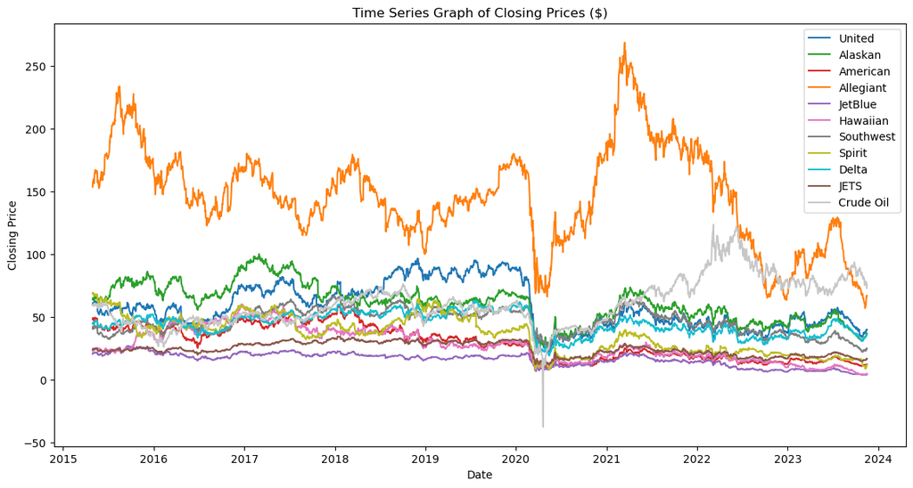

```python
plt.figure(figsize=(14,7))

for airline, df in financ_airlines.items():
    plt.plot(df['Close'], label=airline, color=airline_colors[airline])

plt.title('Time Series Graph of Closing Prices ($)')
plt.xlabel('Date')
plt.ylabel('Closing Price')
plt.legend()

plt.show()
```

A curiosity to note here would be the y-axis (-50 to 300). The graph is indicating there was a time when oil had gone negative. Upon further research, on 4/20/20, oil reached a low of -$37

## Correlational Analysis

This will allow us to calculate how correlated each stock's movement is with one another.

```python
for airline, df in financ_airlines.items():
    df['Daily Return'] = df['Close'].pct_change().dropna()
```

```python
combined_returns = pd.DataFrame()

for airline, df in financ_airlines.items():
    combined_returns[airline] = df['Daily Return']

combined_returns

mean_returns = combined_returns.mean()
cov_returns = combined_returns.cov()
std_returns = combined_returns.std()
```

```python
correlations = {}

# loop through each airline daily returns
for airline1, df1 in financ_airlines.items():
    for airline2, df2 in financ_airlines.items():
        # Avoid calculating correlation with itself
        if airline1 != airline2:
            key = f"{airline1} vs {airline2}"
            correlation = df1['Daily Return'].corr(df2['Daily Return'])
            correlations[key] = correlation

# create an empty df for the correlation matrix
correlation_matrix = pd.DataFrame()

# populate the correlation matrix
for airline1, df1 in financ_airlines.items():
    correlation_matrix[airline1] = [df1['Daily Return'].corr(df2['Daily Return']) for _, df2 in financ_airlines.items()]
```

Creating a correlation matrix so we can examine relationships between shifts in daily returns between all companies.

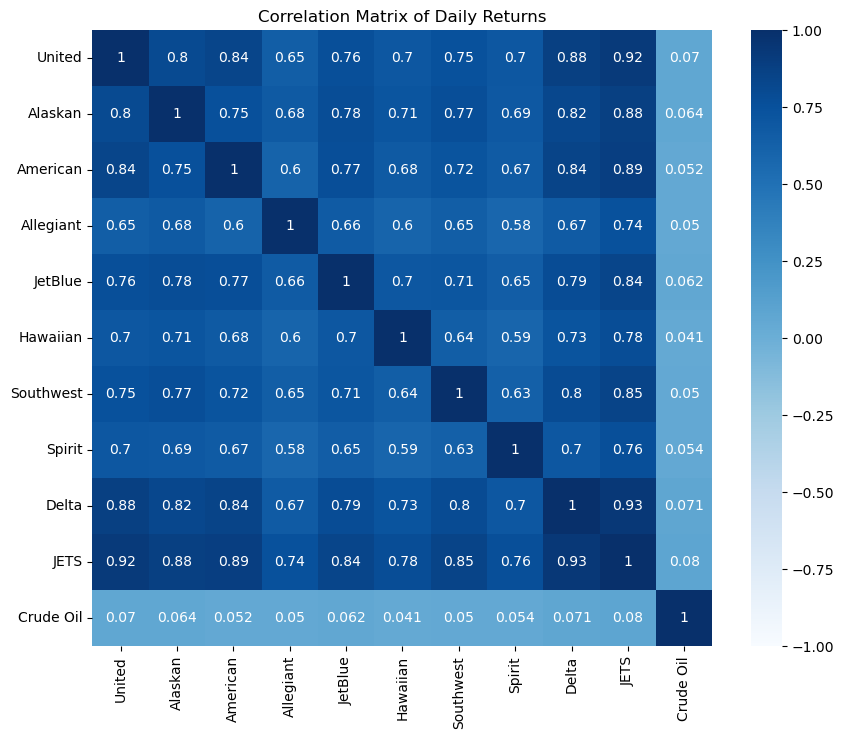

```python
import seaborn as sns

#create correlation matrix3
cmap = sns.diverging_palette(10, 130, as_cmap=True)
plt.figure(figsize=(10, 8))
sns.heatmap(correlation_matrix, annot=True, cmap = 'Blues', vmin=-1, vmax=1,
            xticklabels=correlation_matrix.columns,
            yticklabels=correlation_matrix.columns)
plt.title('Correlation Matrix of Daily Returns')
plt.show()
```

The matrix suggests that while the airline industry's stocks move together to a large extent, external factors like oil prices may not have as immediate or as strong an effect on daily stock movements as one might expect. It would be interesting to analyze these correlations over different time lags or during specific events, such as oil price shocks or global events affecting travel, to see if and how these relationships change.

## Stock Price Trend Transition Probabilities

### Process Overview

1. **For each stock (airline), calculate the daily price change:** $$ \text{Price Change} = \text{Close}_{t} - \text{Close}_{t-1} $$
2. **Label the trend based on the price change:** $$ \text{Trend} = \begin{cases} \text{'up'} & \text{if Price Change} > 0 \\ \text{'down'} & \text{if Price Change} < 0 \\ \text{'no change'} & \text{if Price Change} = 0 \end{cases} $$
3. **Calculate the transition probabilities:**
   - Define the previous day's trend: $$ \text{Prev Trend} = \text{Trend}_{t-1} $$
   - Count the transitions (up-up, down-down, up-down, down-up).
   - Calculate the probabilities of each transition: $$ P(\text{Transition}) = \frac{\text{Count of Transition}}{\text{Total Transitions}} $$

### Transition Matrix

The transition matrix is formed as follows: $$ \begin{array}{|c|c|c|c|c|} \hline \text{Airline} & \text{up-up} & \text{up-down} & \text{down-up} & \text{down-down} \\ \hline \text{Airline 1} & P_{\text{up-up}} & P_{\text{up-down}} & P_{\text{down-up}} & P_{\text{down-down}} \\ \text{Airline 2} & \dots & \dots & \dots & \dots \\ \vdots & \vdots & \vdots & \vdots & \vdots \\ \hline \end{array} $$

Here, *$P_\text{transition type}$ represents the probability of a specific transition type for an airline.*

```python
for airline, df in financ_airlines.items():
    #calculate difference in two day consecutive 'Close' price
    df['Price Change'] = df['Close'].diff()

    #label if price went up or down
    df['Trend'] = df['Price Change'].apply(lambda x: 'up' if x > 0 else ('down' if x < 0 else 'no change'))

def calculate_transition_probabilities(df):
    # shifted column to compare each day's trend with the previous day's
    df['Prev Trend'] = df['Trend'].shift(1)

    # transition state
    transitions = ['up-up', 'down-down', 'up-down', 'down-up']

    # initialize dictionary to hold the counts of each transition
    transition_counts = {transition: 0 for transition in transitions}

    # loop through and count the transitions
    for prev, current in zip(df['Prev Trend'][1:], df['Trend'][1:]):  # Skip the first entry (NaN)
        if prev == 'up' and current == 'up':
            transition_counts['up-up'] += 1
        elif prev == 'down' and current == 'down':
            transition_counts['down-down'] += 1
        elif prev == 'up' and current == 'down':
            transition_counts['up-down'] += 1
        elif prev == 'down' and current == 'up':
            transition_counts['down-up'] += 1

    # sum the total number of transitions and calculate probabilities
    total_transitions = sum(transition_counts.values())
    transition_probabilities = {transition: count / total_transitions for transition, count in transition_counts.items()}
    return transition_probabilities


transitions = ['up-up', 'up-down', 'down-up', 'down-down']

transition_matrix = pd.DataFrame(columns=transitions)

for airline, df in financ_airlines.items():
    transition_probs = calculate_transition_probabilities(df)
    transition_matrix.loc[airline] = transition_probs.values()

print(transition_matrix)
```

```
              up-up   up-down   down-up  down-down
United     0.265764  0.240075  0.247548   0.246614
Alaskan    0.248244  0.240749  0.255738   0.255269
American   0.248705  0.265662  0.243052   0.242581
Allegiant  0.235514  0.265888  0.249065   0.249533
JetBlue    0.225325  0.257102  0.258546   0.259027
Hawaiian   0.232812  0.252726  0.257468   0.256994
Southwest  0.251052  0.244974  0.251987   0.251987
Spirit     0.212518  0.265297  0.261560   0.260626
Delta      0.257654  0.233632  0.255299   0.253415
JETS       0.262458  0.236830  0.249644   0.251068
Crude Oil  0.283701  0.210427  0.252231   0.253640
```

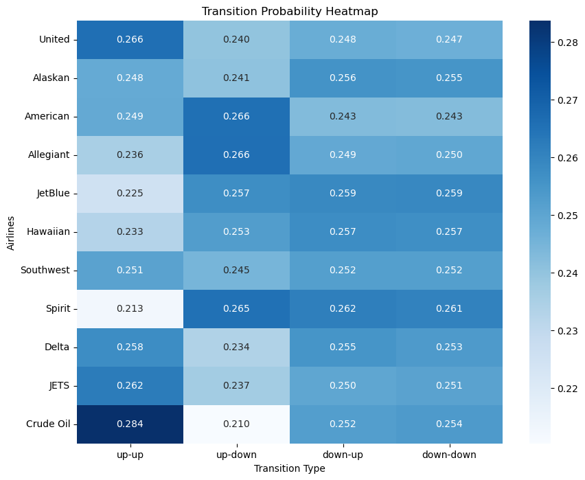

```python
plt.figure(figsize=(10, 8))
plt.title('Transition Probability Heatmap')

sns.heatmap(transition_matrix, annot=True, cmap='Blues', fmt=".3f")

plt.title('Transition Probability Heatmap')
plt.ylabel('Airlines')
plt.xlabel('Transition Type')

plt.show()
```

The heatmap of trend transition probabilities suggests the following:

- Stocks with higher 'up-up' and 'down-down' probabilities might show stronger trend persistence, meaning that once they start moving in a certain direction, they are more likely to continue in that direction for at least another day.
- Conversely, stocks with higher 'up-down' and 'down-up' probabilities tend to have more frequent trend reversals, suggesting higher volatility and possibly less predictable movements.
- The relative size of these probabilities can inform investors about the nature of the stock's price movements, which can be important for trading strategies that depend on momentum or mean reversion.
- Crude oil's high 'up-up' probability could be reflective of its larger market and geopolitical forces that drive its prices, leading to stronger momentum during uptrends.

## Volatility Analysis

The **annualized volatility** ($\ \sigma_{\text{annualized}}\$) is calculated using the formula:

$$ \sigma_{\text{annualized}} = \sigma_{\text{daily}} \times \sqrt{252} $$

where:

- $\sigma_{\text{daily}}$ is the stardard deviation of the stock's daily returns
- 252 is the typical number of trading days in a year.

```python
def calculate_annualized_volatility(daily_returns):
    # calculate the daily standard deviation of returns
    daily_std = np.std(daily_returns)

    # convert daily standard deviation to annualized volatility
    # 252 trading days in a year
    annualized_volatility = daily_std * np.sqrt(252)

    return annualized_volatility

for airline, df in financ_airlines.items():
    volatility = calculate_annualized_volatility(df['Daily Return'])
    print(f"{airline} Volatility: {volatility:.2%}")
```

```
United Volatility: 50.29%
Alaskan Volatility: 40.81%
American Volatility: 52.16%
Allegiant Volatility: 46.08%
JetBlue Volatility: 46.94%
Hawaiian Volatility: 57.38%
Southwest Volatility: 35.48%
Spirit Volatility: 57.40%
Delta Volatility: 40.82%
JETS Volatility: 33.70%
Crude Oil Volatility: 123.14%
```

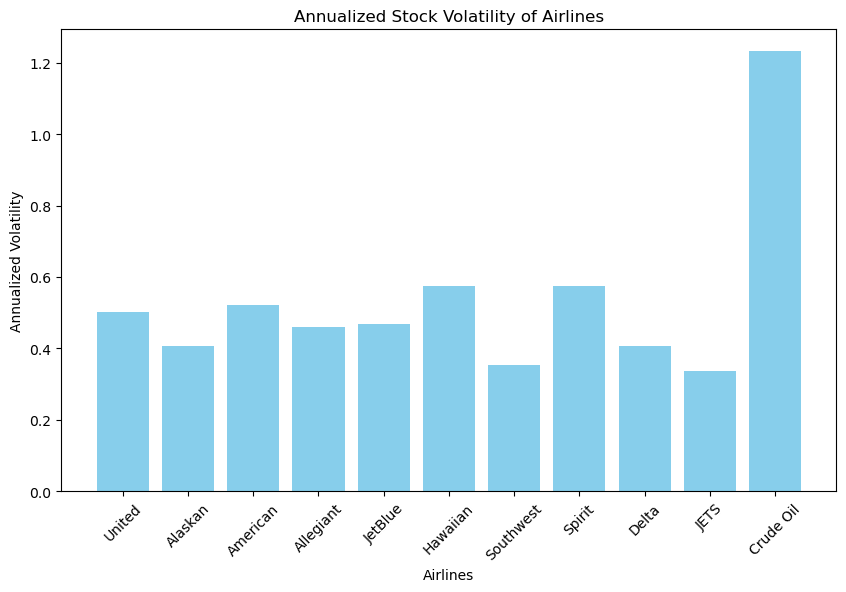

```python
volatilities = {}
for airline, df in financ_airlines.items():
    vol = calculate_annualized_volatility(df['Daily Return'])
    volatilities[airline] = vol

#plot
plt.figure(figsize=(10, 6))
plt.bar(volatilities.keys(), volatilities.values(), color='skyblue')
plt.xlabel('Airlines')
plt.ylabel('Annualized Volatility')
plt.title('Annualized Stock Volatility of Airlines')
plt.xticks(rotation=45)
plt.show()
```

Higher volatility indicates higher risk, which may lead to greater potential for both gain and loss:

- Investors looking for less risky investments might prefer Southwest or JETS.
- Investors with a higher risk tolerance might be attracted to the potential rewards from the higher volatility seen in Hawaiian and Spirit.
- The high volatility of crude oil suggests it is a very risky investment and highlights why airlines might use futures contracts to hedge against this risk.
- Diversification is evident in the JETS ETF, which, by comprising a basket of airline stocks, shows lower volatility than individual airline stocks.

## Sharpe and Sortino Ratio

### Sharpe Ratio

The Sharpe Ratio measures how much excess return received for the extra volatility endured for holding a riskier asset.

The Sharpe Ratio is calculated using the formula:

$$ \text{Sharpe Ratio} = \frac{R_p - R_f}{\sigma_p} $$

where:

- $ R_p $ is the average return of the portfolio (or stock).
- $ R_f $ is the risk-free rate.
- $ \sigma_p $ is the standard deviation of the portfolio’s excess returns.

A higher Sharpe Ratio is better. A negative Sharpe Ratio indicates that the investment's return is less than the risk-free rate.

### Sortino Ratio

Similar to the Sharpe Ratio, the Sortino Ratio also measures risk-adjusted return, but only penalizes negative volatility (downside risk). This ratio designed to focus only on the downside risk of an investment.

The Sortino Ratio is calculated using the formula:

$$ \text{Sortino Ratio} = \frac{R_p - R_f}{\sigma_d} $$

where:

- $ R_p $ is the average return of the portfolio (or stock).
- $ R_f $ is the risk-free rate.
- $ \sigma_d $ is the downside deviation (standard deviation of negative asset returns).

A higher Sortino Ratio indicates a more favorable risk-adjusted return when considering only downside risk.

```python
def calculate_sharpe_ratio(returns, risk_free_rate):
    mean_return = np.mean(returns)
    sd_return = np.std(returns)
    sharpe_ratio = (mean_return - risk_free_rate) / sd_return
    return sharpe_ratio

def calculate_sortino_ratio(returns, risk_free_rate):
    mean_return = np.mean(returns)
    downside_returns = [min(0, r - risk_free_rate) for r in returns]
    downside_deviation = np.std(downside_returns)
    sortino_ratio = (mean_return - risk_free_rate) / downside_deviation
    return sortino_ratio

risk_free_rate = 0.0524  #5.24%

# calculate ratio for each airline
for airline, df in financ_airlines.items():
    sharpe_ratio = calculate_sharpe_ratio(df['Daily Return'], risk_free_rate)
    sortino_ratio = calculate_sortino_ratio(df['Daily Return'], risk_free_rate)
    print(f"{airline} - Sharpe Ratio: {sharpe_ratio:.3f}, Sortino Ratio: {sortino_ratio:.3f}")
```

```
United - Sharpe Ratio: -1.644, Sortino Ratio: -1.892
Alaskan - Sharpe Ratio: -2.036, Sortino Ratio: -2.225
American - Sharpe Ratio: -1.598, Sortino Ratio: -1.881
Allegiant - Sharpe Ratio: -1.804, Sortino Ratio: -2.030
JetBlue - Sharpe Ratio: -1.783, Sortino Ratio: -2.067
Hawaiian - Sharpe Ratio: -1.452, Sortino Ratio: -1.727
Southwest - Sharpe Ratio: -2.344, Sortino Ratio: -2.475
Spirit - Sharpe Ratio: -1.453, Sortino Ratio: -1.741
Delta - Sharpe Ratio: -2.029, Sortino Ratio: -2.234
JETS - Sharpe Ratio: -2.466, Sortino Ratio: -2.663
Crude Oil - Sharpe Ratio: -0.691, Sortino Ratio: -0.707
```

The Sharpe ratio takes into account both the upside and downside volatility, while the Sortino ratio focuses only on the downside risk. The fact that the Sortino ratios are generally more negative than the Sharpe ratios suggests that these stocks have had significant negative returns.

- While all the airlines have negative ratios, the magnitude of the negativity varies. For instance, Hawaiian and Spirit show the least negative Sharpe and Sortino ratios, suggesting they may have performed slightly better relative to their risks compared to others.
- Southwest and JETS have the most negative ratios, indicating they may have underperformed more significantly relative to their risks.
- Crude oil has a less negative Sharpe and Sortino ratio compared to the airline stocks, indicating its performance might be relatively better when considering risk, though it's still underperforming compared to the risk-free rate.

Given our dataset includes COVID-19 and the implications of the lockdown, it makes sense we see negative returns in the airline industry. All flights within the United States were grounded for a couple of months with travel heavily advised against.

## Monte-Carlo Simulation

### Monte Carlo Simulation for Portfolio Optimization

A Monte Carlo simulation is used to explore the optimal allocation of a portfolio of airline stocks. This process involves generating a large number of random portfolios (simulations) and evaluating their performance. The key steps include:

1. **Initialization of Storage Arrays:**
   - A matrix `all_weights` to store the asset weights for each simulated portfolio.
   - Arrays `return_arr`, `volatility_arr`, and `sharpe_arr` to store the expected return, volatility, and Sharpe Ratio for each portfolio, respectively.
2. **Simulation Process:**
   - Randomly generate portfolio weights, normalize them to sum to 1, and store them in `all_weights`.
   - Calculate the expected annual return for each portfolio by summing the product of the mean daily returns and the portfolio weights, scaled to an annual basis (multiplied by 252, the typical number of trading days in a year).
   - Compute the expected annual volatility for each portfolio using the annualized covariance matrix of stock returns.
   - Determine the Sharpe Ratio for each portfolio, representing the risk-adjusted return.
3. **Optimization Outcome:**
   - Identify the portfolio with the highest Sharpe Ratio, representing the optimal risk-adjusted performance based on historical data.
4. **Extraction of Optimal Portfolio Weights:**
   - Retrieve the weights of the portfolio that achieved the maximum Sharpe Ratio, indicating the proportion of total investment to allocate to each stock.

The result is a theoretically optimized portfolio based on past performance, which may guide investment decisions.

```python
num_portfolios = 10000  # 10000 simulations
all_weights = np.zeros((num_portfolios, len(combined_returns.columns)))
return_arr = np.zeros(num_portfolios)
volatility_arr = np.zeros(num_portfolios)
sharpe_arr = np.zeros(num_portfolios)

for i in range(num_portfolios):
    # create random weight vector
    weights = np.array(np.random.random(len(combined_returns.columns)))
    weights = weights / np.sum(weights)

    # save weights
    all_weights[i, :] = weights

    # expected return
    return_arr[i] = np.sum((combined_returns.mean() * weights * 252))

    # expected volatility
    volatility_arr[i] = np.sqrt(np.dot(weights.T, np.dot(combined_returns.cov() * 252, weights)))

    # sharpe ratio
    sharpe_arr[i] = return_arr[i] / volatility_arr[i]

max_sharpe_ratio = sharpe_arr.max()
max_sharpe_idx = sharpe_arr.argmax()
max_sharpe_weights = all_weights[max_sharpe_idx, :]
```

```python
print(f"Maximum Sharpe Ratio: {max_sharpe_ratio:.2f}")
```

```
Maximum Sharpe Ratio: 0.06
```

```python
print("Weights of the Best Portfolio:")
for stock, weight in zip(combined_returns.columns, max_sharpe_weights):
    print(f"{stock}: {weight:.2%}")
```

```
Weights of the Best Portfolio:
United: 19.85%
Alaskan: 15.80%
American: 2.57%
Allegiant: 3.62%
JetBlue: 8.03%
Hawaiian: 5.66%
Southwest: 9.48%
Spirit: 2.30%
Delta: 22.31%
JETS: 10.12%
Crude Oil: 0.26%
```

```python
best_portfolio_return = return_arr[max_sharpe_idx]
best_portfolio_volatility = volatility_arr[max_sharpe_idx]

print(f"Expected Annual Return of the Best Portfolio: {best_portfolio_return:.2%}")
print(f"Expected Annual Volatility of the Best Portfolio: {best_portfolio_volatility:.2%}")
```

```
Expected Annual Return of the Best Portfolio: 2.44%
Expected Annual Volatility of the Best Portfolio: 39.45%
```

The "best" portfolio's return is relatively modest, suggesting that the stocks in question may not offer high returns or that the simulation period included bearish market conditions.

The expected volatility is high, suggesting that the portfolio experiences to a considerable amount of risk. However, the "best" portfolio's volatility is the less than the industry mean volatility.

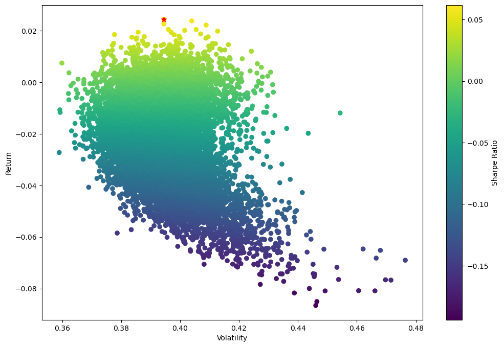

```python
plt.figure(figsize=(12,8))
plt.scatter(volatility_arr, return_arr, c=sharpe_arr, cmap='viridis')
plt.colorbar(label='Sharpe Ratio')
plt.xlabel('Volatility')
plt.ylabel('Return')

# Mark the point with the highest Sharpe ratio
plt.scatter(volatility_arr[max_sharpe_idx], return_arr[max_sharpe_idx], c='red', s=50, marker='*', label='Maximum Sharpe Ratio')
```

# Marketing Carrier On-Time Performance Data

## Marketing Carrier On-Time Performance Data ETL

This flight data was obtained from the Bureau of Transportation Statistics Airline On-Time Performance Data Base. The data table used for the following data is Marketing Carrier On-Time Performance (Beginning January 2018).

[On-Time : Marketing Carrier On-Time Performance (Beginning January 2018)](https://www.transtats.bts.gov/Fields.asp?gnoyr_VQ=FGK)

```python
# Load in flight Data
flight_cols = ['MKT_UNIQUE_CARRIER', 'OP_UNIQUE_CARRIER','YEAR', 'QUARTER', 'MONTH', 'DAY_OF_MONTH',
       'DAY_OF_WEEK', 'FL_DATE', 'MKT_CARRIER','OP_CARRIER', 'TAIL_NUM',
        'ORIGIN', 'DEST','CRS_DEP_TIME', 'DEP_TIME', 'DEP_DELAY',
        'DEP_DELAY_NEW', 'DEP_DEL15','DEP_DELAY_GROUP',
        'TAXI_OUT', 'WHEELS_OFF','WHEELS_ON', 'TAXI_IN', 'CRS_ARR_TIME',
        'ARR_TIME', 'ARR_DELAY','ARR_DELAY_NEW', 'ARR_DEL15', 'ARR_DELAY_GROUP',
        'CANCELLED', 'DIVERTED']

airline_code = ['AA', 'DL', 'WN', 'UA', 'AS', 'F9', 'HA', 'G4', 'B6', 'NK']
file_dict = {}
for airline in airline_code:
  file_dict[airline] = glob.glob('../cmps3160-project/202*-*/{}*.csv'.format(airline))
```

Due to upload size restrictions on git the orginal files had to be broken into multiple smaller files. Below the function combines all files with the same market carrier into one DataFrame.

```python
def df_airline(input):
  frame  = pd.read_csv(file_dict[input][0], usecols = flight_cols)
  for file in file_dict[input][1:]:
    frame2 = pd.read_csv(file, usecols = flight_cols)
    frame = pd.concat([frame, frame2], ignore_index=True)
  frame['FL_DATE'] = frame['FL_DATE'].apply(lambda x: x[:-12])
  frame['FL_DATE'] = pd.to_datetime(frame['FL_DATE'])
  return frame
```

```python
df_AA = df_airline('AA') # american
df_DL = df_airline('DL') # delta
df_WN = df_airline('WN') # southwest
df_UA = df_airline('UA') # united
df_AS = df_airline('AS') # alaskan
df_NK = df_airline('NK') # spirit
df_HA = df_airline('HA') # hawaiian
df_G4 = df_airline('G4') # allegiant
df_B6 = df_airline('B6') # jetblue
df_F9 = df_airline('F9') # frontier

flight_airlines = {'AA':df_AA, 'DL':df_DL, 'WN':df_WN,
                        'UA':df_UA, 'AS':df_AS, 'NK': df_NK,
                        'HA':df_HA, 'G4':df_G4, 'B6':df_B6,
                        'F9':df_F9}
```

The following is a DataFrame with all flights that took place from June 2022 to June 2023. Each row of the DataFrame corresponds to one flight.

```python
flight_data = pd.concat([df_AA, df_DL, df_WN, df_UA, df_AS, df_NK, df_HA, df_G4, df_B6, df_F9], axis=0)
```

```python
flight_data.head()
```

|  | MKT_UNIQUE_CARRIER | YEAR | QUARTER | MONTH | DAY_OF_MONTH | DAY_OF_WEEK | FL_DATE | MKT_CARRIER | OP_UNIQUE_CARRIER | OP_CARRIER | ... | WHEELS_ON | TAXI_IN | CRS_ARR_TIME | ARR_TIME | ARR_DELAY | ARR_DELAY_NEW | ARR_DEL15 | ARR_DELAY_GROUP | CANCELLED | DIVERTED |
| --- | --- | --- | --- | --- | --- | --- | --- | --- | --- | --- | --- | --- | --- | --- | --- | --- | --- | --- | --- | --- | --- |
| 0 | AA | 2022 | 4 | 11 | 1 | 2 | 2022-11-01 | AA | AA | AA | ... | 1032.0 | 8.0 | 1016 | 1040.0 | 24.0 | 24.0 | 1.0 | 1.0 | 0.0 | 0.0 |
| 1 | AA | 2022 | 4 | 11 | 1 | 2 | 2022-11-01 | AA | AA | AA | ... | 541.0 | 12.0 | 600 | 553.0 | -7.0 | 0.0 | 0.0 | -1.0 | 0.0 | 0.0 |
| 2 | AA | 2022 | 4 | 11 | 1 | 2 | 2022-11-01 | AA | AA | AA | ... | 1325.0 | 11.0 | 1355 | 1336.0 | -19.0 | 0.0 | 0.0 | -2.0 | 0.0 | 0.0 |
| 3 | AA | 2022 | 4 | 11 | 1 | 2 | 2022-11-01 | AA | AA | AA | ... | 1102.0 | 4.0 | 1112 | 1106.0 | -6.0 | 0.0 | 0.0 | -1.0 | 0.0 | 0.0 |
| 4 | AA | 2022 | 4 | 11 | 1 | 2 | 2022-11-01 | AA | AA | AA | ... | 1844.0 | 21.0 | 1842 | 1905.0 | 23.0 | 23.0 | 1.0 | 1.0 | 0.0 | 0.0 |

5 rows × 31 columns

The function delay below calculate the number of delays that the market carrier airline has each day. This can be used to calculate the number of arrival delays or departure delays. The FAA considers a flight that is more that 15 minutes late delay. The columns DEP_DEL15 and ARR_DEL15 are binary with 0 representing not delayed and 1 representing delayed.

```python
# Calculate number of delays using the binary column DEP_DEL15 or ARR_DEL15
def delays(DataFrame, airline, column):
  df = DataFrame.groupby('FL_DATE')[column].sum()
  df.rename('{a}_NUM_{b}'.format(a=airline, b=column), inplace=True)
  return df
```

The following function counts the number of flights an airline as the market carrier flies and the number of cancelations that the airline has in a given day as the market carrier. Two series are created one that counts the number of flights each day and one that counts the number of cancelations each day.

```python
# Calculates the number of flight per day and number of cancelations per day
def num_flights(DataFrame, airline):
  cancelled = DataFrame.groupby('CANCELLED')
  df_FL = cancelled.get_group(0)['FL_DATE'].value_counts()
  df_FL.rename('{}_NUM_FL'.format(airline), inplace=True)

  df_CAN = cancelled.get_group(1)['FL_DATE'].value_counts()
  df_CAN.rename('{}_NUM_CAN'.format(airline), inplace=True)
  return df_FL, df_CAN
```

Using the functions above a DataFrame is created with each market carrier airline series as a column. Each of the functions below has the flight date as the index and the values indicated in the comments for each airline are the columns of the DataFrame.

```python
# Number of Departure Delays
df_DEP_DEL = delays(df_AA, 'AA', 'DEP_DEL15')

# Number of Arrival Delays
df_ARR_DEL = delays(df_AA, 'AA', 'ARR_DEL15')

# DataFrames for Number of Flights and Number of Cancelations
df_NUM_FL, df_NUM_CAN = num_flights(df_AA, 'AA')

# Proportion of ALL flights that are canceled
df_PROP_CAN_FL = pd.DataFrame()
df_PROP_CAN_FL['AA_PROP_CAN_FL'] = df_NUM_CAN/df_NUM_FL


for airline in airline_code[1:]:
  df_DEP_DEL = pd.concat([df_DEP_DEL, delays(flight_airlines[airline], airline, 'DEP_DEL15')], axis=1)
  df_ARR_DEL = pd.concat([df_ARR_DEL, delays(flight_airlines[airline], airline,'ARR_DEL15')], axis=1)

  num_fl, num_can = num_flights(flight_airlines[airline], airline)
  prop = pd.DataFrame()
  prop['{}_PROP_CAN_FL'.format(airline)] = num_can / num_fl
  df_NUM_FL = pd.concat([df_NUM_FL, num_fl], axis=1)
  df_NUM_CAN = pd.concat([df_NUM_CAN, num_can], axis=1)
  df_PROP_CAN_FL = pd.concat([df_PROP_CAN_FL, prop], axis=1)

df_DEP_DEL = df_DEP_DEL.sort_index()
df_ARR_DEL = df_ARR_DEL.sort_index()
df_NUM_FL = df_NUM_FL.sort_index()
df_NUM_CAN = df_NUM_CAN.sort_index()
df_PROP_CAN_FL =  df_PROP_CAN_FL.sort_index()
```

## Flight Data EDA

The bar plot below so the total daily departure delays for all market carrier airlines. The bar plot is a stacked bar plot with various colors showing that airlines number of delays. Since departure delays often result in arrival delays the plots very simillar.

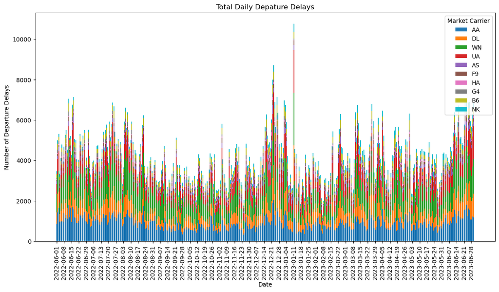

```python
# Plotting Total Daily Depature Delays
fig, ax = plt.subplots(figsize=(14,7))

bottom = np.zeros(len(df_ARR_DEL))
for col in df_DEP_DEL.columns:
  p = ax.bar(df_DEP_DEL.index.strftime('%Y-%m-%d'), df_DEP_DEL[col], label = col[0:2], bottom = bottom)
  bottom += df_DEP_DEL[col]

plt.title('Total Daily Depature Delays')
plt.xlabel('Date')
plt.ylabel('Number of Departure Delays')
ax.set_xticks(ax.get_xticks()[::7])
plt.xticks(rotation=90)
ax.legend(title = 'Market Carrier', loc='upper right')
plt.show()
```

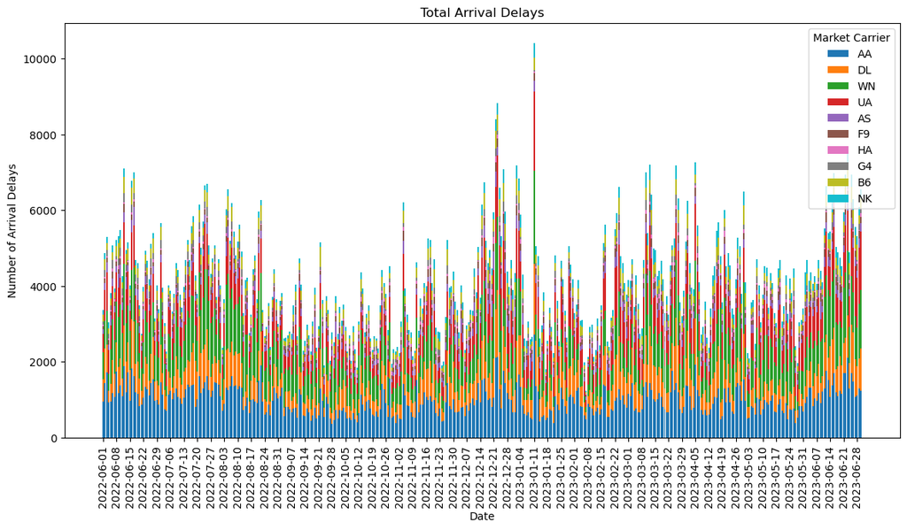

```python
# Plotting Total Daily Arrival Delays
fig, ax = plt.subplots(figsize=(14,7))

bottom = np.zeros(len(df_ARR_DEL))
for col in df_ARR_DEL.columns:
  p = ax.bar(df_ARR_DEL.index.strftime('%Y-%m-%d'), df_ARR_DEL[col], label = col[0:2], bottom = bottom)
  bottom += df_ARR_DEL[col]

plt.title('Total Arrival Delays')
plt.xlabel('Date')
plt.ylabel('Number of Arrival Delays')
ax.set_xticks(ax.get_xticks()[::7])
plt.xticks(rotation=90)
ax.legend(title = 'Market Carrier', loc='upper right')
plt.show()
```

Another way to plot departure delays is to look at the delays by airline. A line plot was used to show this below.

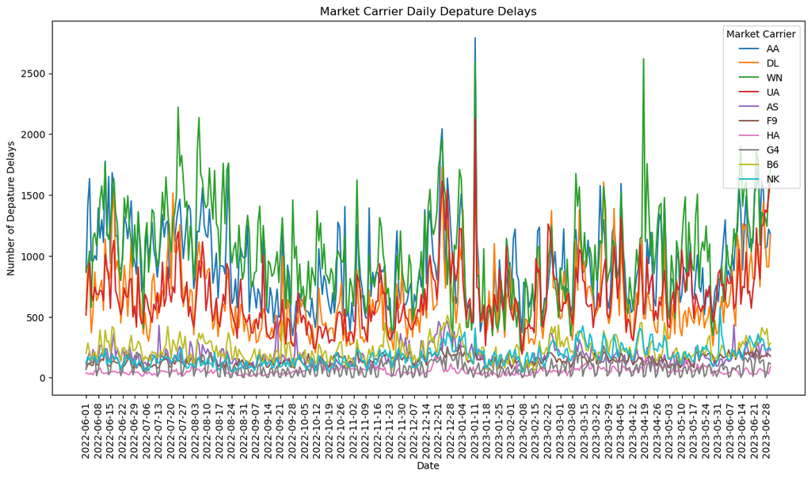

```python
# Plotting Market Carrier Daily Depature Delays
fig, ax = plt.subplots(figsize=(14,7))
legend_DEP_DEL = {}
for col in df_DEP_DEL.columns:
  plt.plot(df_DEP_DEL.index.strftime('%Y-%m-%d'), df_DEP_DEL[col])
  legend_DEP_DEL[col[0:2]] = col

plt.title('Market Carrier Daily Depature Delays')
plt.xlabel('Date')
plt.ylabel('Number of Depature Delays')
ax.set_xticks(ax.get_xticks()[::7])
plt.xticks(rotation=90)
ax.legend(legend_DEP_DEL, title = 'Market Carrier', loc='upper right')
plt.show()
```

The next two plots show the number of flights by airline and the number of cancelations by airline.

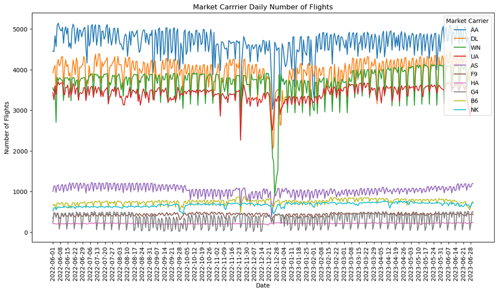

```python
#Plotting Market Carrier Daily Number of Flights

fig, ax = plt.subplots(figsize=(14,7))
legend_NUM_FL= {}
for col in df_NUM_FL.columns:
  plt.plot(df_NUM_FL.index.strftime('%Y-%m-%d'), df_NUM_FL[col])
  legend_NUM_FL[col[0:2]] = col

plt.title('Market Carrrier Daily Number of Flights')
plt.xlabel('Date')
plt.ylabel('Number of Flights')
ax.set_xticks(ax.get_xticks()[::7])
plt.xticks(rotation=90)
ax.legend(legend_NUM_FL, title = 'Market Carrier', loc='upper right')
plt.show()
```

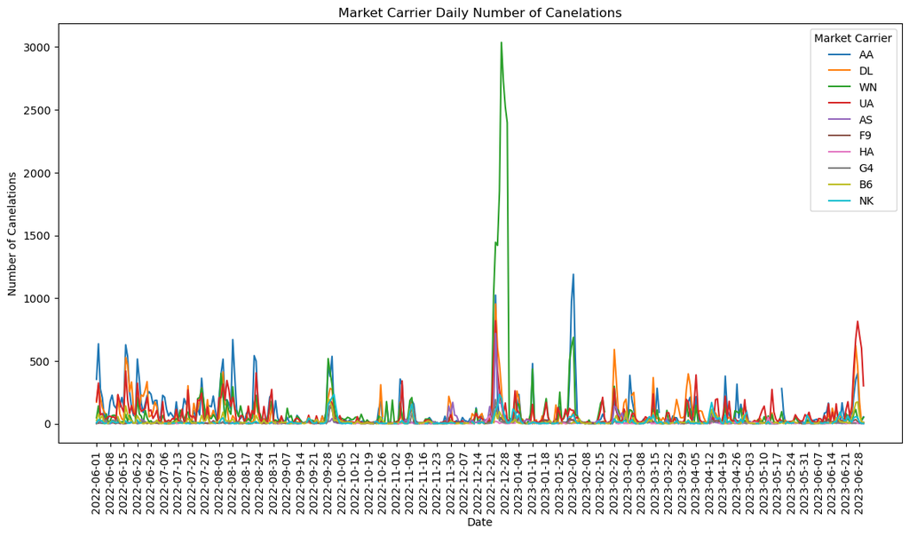

```python
#Plotting Market Carrier Daily Number of Cancelations

fig, ax = plt.subplots(figsize=(14,7))
legend_NUM_CAN= {}
for col in df_NUM_CAN.columns:
  plt.plot(df_NUM_CAN.index.strftime('%Y-%m-%d'), df_NUM_CAN[col])
  legend_NUM_CAN[col[0:2]] = col

plt.title('Market Carrier Daily Number of Canelations')
plt.xlabel('Date')
plt.ylabel('Number of Canelations')
ax.set_xticks(ax.get_xticks()[::7])
plt.xticks(rotation=90)
ax.legend(legend_NUM_CAN, title = 'Market Carrier', loc='upper right')
plt.show()
```

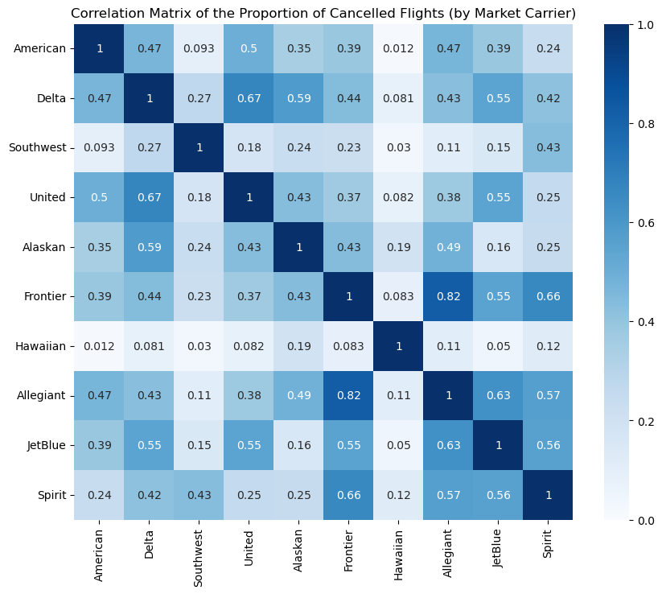

```python
# Create a Correlation Martix for the Proportion of Cancelled Flights by Market Carrier
MKT_code = {'AA':'American', 'DL':'Delta', 'WN':'Southwest',
                        'UA':'United', 'AS': 'Alaskan', 'NK':'Spirit',
                        'HA':'Hawaiian', 'G4':'Allegiant', 'B6':'JetBlue',
                        'F9':'Frontier'}

prop_can_corr_matrix = df_PROP_CAN_FL.corr()

label_names = []

for item in list(prop_can_corr_matrix.columns):
  code = item[0:2]
  name = MKT_code[code]
  label_names.append(name)

cmap = sns.diverging_palette(10, 130, as_cmap=True)
plt.figure(figsize=(10, 8))
sns.heatmap(prop_can_corr_matrix, annot=True, cmap = 'Blues', vmin=0, vmax=1,
            xticklabels=label_names,
            yticklabels=label_names)
plt.title('Correlation Matrix of the Proportion of Cancelled Flights (by Market Carrier)')
plt.show()
```

Since some market carriers use operating carriers to fulfil some of their flights. Looking at the proportion of a market carriers flights that are not operated by the market carrier could help to indicate the market carriers current demands.

```python
def inner_op_mkt(mkt_carrier, airline):
  df = mkt_carrier[airline].to_frame().rename(columns={'FL_DATE':'NUM_SCH_FL'}).reset_index()
  df = df.set_index('FL_DATE')

  op_not_mkt = df[df['OP_UNIQUE_CARRIER']!= airline]
  op_not_mkt = op_not_mkt['NUM_SCH_FL'].rename('OP_NOT_MKT').to_frame().reset_index()
  op_not_mkt = op_not_mkt.groupby('FL_DATE')['OP_NOT_MKT'].sum()

  op_mkt = df[df['OP_UNIQUE_CARRIER'] == airline]
  op_mkt = op_mkt['NUM_SCH_FL'].rename('OP_MKT')

  df_mkt = op_mkt.to_frame().join(op_not_mkt, on='FL_DATE')
  df_mkt['PROP_OP_BY_MKT'] = df_mkt['OP_MKT']/(df_mkt['OP_MKT']+ df_mkt['OP_NOT_MKT'])

  df_mkt = df_mkt.drop(['OP_MKT', 'OP_NOT_MKT'], axis=1)
  return df_mkt
```

```python
# status {0, 1}
# Flights = 0
# Canceled = 1
def all_op_mkt(status):
  if status == 0 or  status == 1:
    flights_status = flight_data.groupby('CANCELLED')
    fl_status = flights_status.get_group(status)
  else:
    return None
  airline_code = ['AA', 'DL', 'WN', 'UA', 'AS', 'F9', 'HA', 'G4', 'B6', 'NK']

  mkt_carrier = fl_status.groupby(['MKT_UNIQUE_CARRIER', 'OP_UNIQUE_CARRIER'])['FL_DATE'].value_counts()
  df_op_mkt = inner_op_mkt(mkt_carrier, airline_code[0]).add_suffix('_{}'.format(airline_code[0]))

  for airline in airline_code[1:]:
    df_mkt = inner_op_mkt(mkt_carrier, airline)
    if  df_mkt['PROP_OP_BY_MKT'].isnull().all() == True:
      continue
    else:
      df_mkt = df_mkt.add_suffix('_{}'.format(airline))

    df_op_mkt = df_op_mkt.join(df_mkt, on='FL_DATE')

  df_op_mkt.dropna(how='all', axis=1, inplace=True)
  df_op_mkt.fillna(0, inplace=True)
  df_op_mkt = df_op_mkt.sort_index()

  return df_op_mkt
```

```python
FL_op_mkt = all_op_mkt(0) # only flights
CAN_op_mkt = all_op_mkt(1) # only cancelled flight
```

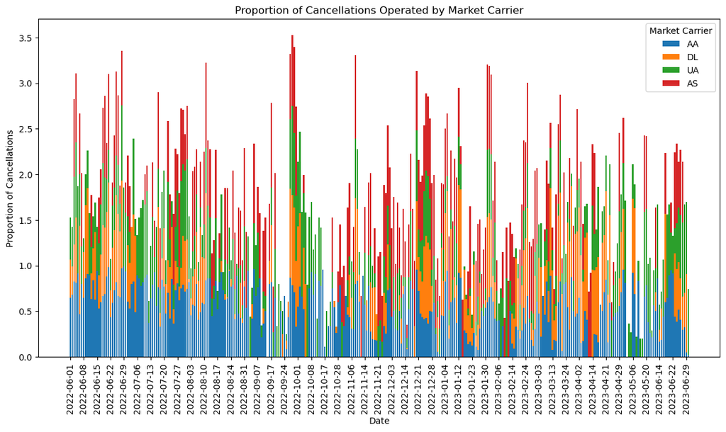

```python
# Plotting Proportion of cancelations operated by the market carrier
fig, ax = plt.subplots(figsize=(14,7))

bottom = np.zeros(len( CAN_op_mkt))
for col in CAN_op_mkt.columns:
  p = ax.bar(CAN_op_mkt.index.strftime('%Y-%m-%d'), CAN_op_mkt[col], label = col[-2:], bottom = bottom)
  bottom += CAN_op_mkt[col]

plt.title('Proportion of Cancellations Operated by Market Carrier')
plt.xlabel('Date')
plt.ylabel('Proportion of Cancellations')
ax.set_xticks(ax.get_xticks()[::7])
plt.xticks(rotation=90)
ax.legend(title = 'Market Carrier', loc='upper right')
plt.show()
```

# Air Carrier Statistics (Form 41 Traffic)- U.S. Carriers

[Data Base Profile](https://www.transtats.bts.gov/DatabaseInfo.asp?QO_VQ=EED&DB_URL=)

## T-100 Domestic Segment (U.S. Carriers) Data ETL

This flight data was obtained from the Bureau of Transportation Statistics Air Carrier Statistics (Form 41 Traffic)- U.S. Carriers Data Base. The data table used for the following data is T-100 Domestic Segment (U.S. Carriers). This data table contains monthly domestic non-stop segment data reported by U.S. air carriers.

[T-100 Domestic Segment (U.S. Carriers)](https://www.transtats.bts.gov/Fields.asp?gnoyr_VQ=FIM)

```python
# Load in T-100 Domestic Segment (U.S. Carriers)
T_100_lst = glob.glob('../cmps3160-project/T-100 Domestic Segment (U.S. Carriers)/*.csv')
```

```python
df_air_stats = pd.read_csv(T_100_lst[0])

for item in T_100_lst[1:]:
  frame =  pd.read_csv(item)
  df_air_stats = pd.concat([df_air_stats, frame], ignore_index=True)
```

```python
df_air_stats.head()
```

|  | UNIQUE_CARRIER | DEPARTURES_SCHEDULED | DEPARTURES_PERFORMED | PAYLOAD | SEATS | PASSENGERS | FREIGHT | MAIL | DISTANCE | RAMP_TO_RAMP | ... | DEST_STATE_NM | DEST_WAC | AIRCRAFT_GROUP | AIRCRAFT_TYPE | AIRCRAFT_CONFIG | YEAR | QUARTER | MONTH | DISTANCE_GROUP | CLASS |
| --- | --- | --- | --- | --- | --- | --- | --- | --- | --- | --- | --- | --- | --- | --- | --- | --- | --- | --- | --- | --- | --- |
| 0 | YX | 0.0 | 1.0 | 19092.0 | 70.0 | 0.0 | 0.0 | 0.0 | 95.0 | 42.0 | ... | Maine | 12 | 6 | 677 | 1 | 2022 | 1 | 2 | 1 | F |
| 1 | YX | 0.0 | 1.0 | 19092.0 | 70.0 | 0.0 | 0.0 | 0.0 | 121.0 | 151.0 | ... | Michigan | 43 | 6 | 677 | 1 | 2022 | 1 | 1 | 1 | F |
| 2 | YX | 0.0 | 1.0 | 19092.0 | 70.0 | 0.0 | 0.0 | 0.0 | 151.0 | 130.0 | ... | Pennsylvania | 23 | 6 | 677 | 1 | 2022 | 1 | 3 | 1 | F |
| 3 | YX | 0.0 | 1.0 | 19092.0 | 70.0 | 10.0 | 0.0 | 0.0 | 629.0 | 140.0 | ... | Pennsylvania | 23 | 6 | 677 | 1 | 2022 | 3 | 7 | 2 | F |
| 4 | YX | 0.0 | 1.0 | 19092.0 | 70.0 | 12.0 | 0.0 | 0.0 | 182.0 | 64.0 | ... | Ohio | 44 | 6 | 677 | 1 | 2022 | 1 | 1 | 1 | F |

5 rows × 45 columns

```python
df_stat_groups = df_air_stats.groupby('UNIQUE_CARRIER')
```

```python
full_seats={}
freight_weight={}
```

```python
# Proportion of Full Seats
for airline in airline_code:
  inner_dict = {}
  yr_month_group = df_air_stats.groupby(['YEAR', 'MONTH'])
  for i in yr_month_group.groups.keys():
    frame = yr_month_group.get_group(i)
    yr = frame['YEAR'].unique().tolist()[0]
    month = frame['MONTH'].unique().tolist()[0]
    month_prop_full = frame['PASSENGERS'].sum() / frame['SEATS'].sum()
    inner_dict[i] = month_prop_full
  full_seats[airline] = inner_dict
```

```python
# Proportion of Weight from Freight and Mail
for airline in airline_code:
  inner_dict = {}
  yr_month_group = df_air_stats.groupby(['YEAR', 'MONTH'])
  for i in yr_month_group.groups.keys():
    frame = yr_month_group.get_group(i)
    yr = frame['YEAR'].unique().tolist()[0]
    month = frame['MONTH'].unique().tolist()[0]
    month_prop_freight = (frame['FREIGHT'].sum() + frame['MAIL'].sum())/ frame['PAYLOAD'].sum()
    inner_dict[i] = month_prop_freight
  freight_weight[airline] = inner_dict
```

```python
# DataFrames of proportion of full seats and proportion of weight from freight and mail
df_full_seats = pd.DataFrame.from_dict(full_seats).add_suffix('_PROP_FULL_SEATS')
df_freight_weight = pd.DataFrame.from_dict(freight_weight).add_suffix('_PROP_FREIGHT/MAIL')
df_full_seats.index.rename(['YEAR', 'MONTH'], inplace=True)
df_freight_weight.index.rename(['YEAR', 'MONTH'], inplace=True)
```

```python
# Dictionary of all flight metrics DataFrames
flight_metics = {'Departure' : df_DEP_DEL, 'Arrival' : df_ARR_DEL,
                 'Fight Count' : df_NUM_FL, 'Cancel Count': df_NUM_CAN,
                 'Prop Flights Operated by Market' : FL_op_mkt,
                 'Prop Canceled Operated by Market' : CAN_op_mkt,
                 'Prop Full Seats' : df_full_seats, 'Prop Freight/Mail': df_freight_weight
                 }
```

```python
carrier_group_dict = {'1':'Regional Carriers (including Large, Medium, Commuter, Small Certified)',
                      '2':'National Carriers', '3':'Major Carriers'}

T100_carrier_groups = df_air_stats.groupby(['CARRIER_GROUP', 'YEAR', 'MONTH'])

T100_mean = T100_carrier_groups['DEPARTURES_SCHEDULED', 'DEPARTURES_PERFORMED', 'PAYLOAD', 'SEATS', 'PASSENGERS',
 'FREIGHT', 'MAIL', 'DISTANCE', 'RAMP_TO_RAMP', 'AIR_TIME', 'DISTANCE_GROUP'].mean()

Major_Mean = T100_mean.loc[3, :].add_prefix('Major_Carriers_Mean_')
National_Mean = T100_mean.loc[2, :].add_prefix('National_Carriers_Mean_')
Regional_Mean = T100_mean.loc[2, :].add_prefix('Regional_Carriers_Mean_')
```

```python
df_air_stats.head()
```

|  | UNIQUE_CARRIER | DEPARTURES_SCHEDULED | DEPARTURES_PERFORMED | PAYLOAD | SEATS | PASSENGERS | FREIGHT | MAIL | DISTANCE | RAMP_TO_RAMP | ... | DEST_STATE_NM | DEST_WAC | AIRCRAFT_GROUP | AIRCRAFT_TYPE | AIRCRAFT_CONFIG | YEAR | QUARTER | MONTH | DISTANCE_GROUP | CLASS |
| --- | --- | --- | --- | --- | --- | --- | --- | --- | --- | --- | --- | --- | --- | --- | --- | --- | --- | --- | --- | --- | --- |
| 0 | YX | 0.0 | 1.0 | 19092.0 | 70.0 | 0.0 | 0.0 | 0.0 | 95.0 | 42.0 | ... | Maine | 12 | 6 | 677 | 1 | 2022 | 1 | 2 | 1 | F |
| 1 | YX | 0.0 | 1.0 | 19092.0 | 70.0 | 0.0 | 0.0 | 0.0 | 121.0 | 151.0 | ... | Michigan | 43 | 6 | 677 | 1 | 2022 | 1 | 1 | 1 | F |
| 2 | YX | 0.0 | 1.0 | 19092.0 | 70.0 | 0.0 | 0.0 | 0.0 | 151.0 | 130.0 | ... | Pennsylvania | 23 | 6 | 677 | 1 | 2022 | 1 | 3 | 1 | F |
| 3 | YX | 0.0 | 1.0 | 19092.0 | 70.0 | 10.0 | 0.0 | 0.0 | 629.0 | 140.0 | ... | Pennsylvania | 23 | 6 | 677 | 1 | 2022 | 3 | 7 | 2 | F |
| 4 | YX | 0.0 | 1.0 | 19092.0 | 70.0 | 12.0 | 0.0 | 0.0 | 182.0 | 64.0 | ... | Ohio | 44 | 6 | 677 | 1 | 2022 | 1 | 1 | 1 | F |

5 rows × 45 columns

# Combining All Data Sets by the Market Airline

Combining Airline Operations Performance Metrics and Stock data.

## Airline Operations Performance Metrics

Airline Operations Performance Metrics were created using the Marketing Carrier On-Time Performance data and the T-100 Domestic Segment (U.S. Carriers) data.

```python
df_AA_op_stat = pd.DataFrame() # american
df_DL_op_stat = pd.DataFrame() # delta
df_WN_op_stat = pd.DataFrame() # southwest
df_UA_op_stat = pd.DataFrame() # united
df_AS_op_stat = pd.DataFrame() # alaskan
df_NK_op_stat = pd.DataFrame() # spirit
df_HA_op_stat = pd.DataFrame() # hawaiian
df_G4_op_stat = pd.DataFrame() # allegiant
df_B6_op_stat = pd.DataFrame() # jetblue
df_F9_op_stat = pd.DataFrame() # frontier

airlines_operations_stats = {'AA':df_AA_op_stat, 'DL':df_DL_op_stat, 'WN':df_WN_op_stat,
                        'UA':df_UA_op_stat, 'AS':df_AS_op_stat, 'NK': df_NK_op_stat,
                        'HA':df_HA_op_stat, 'G4':df_G4_op_stat, 'B6':df_B6_op_stat,
                        'F9':df_F9_op_stat}
```

```python
def T100_stat_by_airline(summ_stat_frame, type):
  dataframe2  = pd.DataFrame()
  date_range = pd.date_range(start="2022-06-01",end="2023-06-30")
  dataframe2['FL_DATE'] = date_range
  dataframe2['YEAR'] = pd.DatetimeIndex(dataframe2['FL_DATE']).year
  dataframe2['MONTH'] = pd.DatetimeIndex(dataframe2['FL_DATE']).month

  df_mean_stats = summ_stat_frame.loc[airline].add_prefix('{a}_{b}_'.format(a=airline, b=type))
  df_mean_stats = pd.merge(dataframe2, df_mean_stats, on=['YEAR', 'MONTH'])
  df_mean_stats.drop(['YEAR', 'MONTH'], axis=1, inplace=True)
  df_mean_stats.set_index('FL_DATE', inplace=True)
  return df_mean_stats
```

```python
df_airline_stat = df_air_stats.groupby(['UNIQUE_CARRIER', 'YEAR', 'MONTH'])
df_mean_stats = df_airline_stat[['DEPARTURES_SCHEDULED', 'DEPARTURES_PERFORMED', 'PAYLOAD', 'SEATS', 'PASSENGERS','FREIGHT', 'MAIL', 'DISTANCE', 'RAMP_TO_RAMP', 'AIR_TIME']].mean()
df_std_stats = df_airline_stat[['DEPARTURES_SCHEDULED', 'DEPARTURES_PERFORMED', 'PAYLOAD', 'SEATS', 'PASSENGERS','FREIGHT', 'MAIL', 'DISTANCE', 'RAMP_TO_RAMP', 'AIR_TIME']].std()
df_median_stats = df_airline_stat[['DEPARTURES_SCHEDULED', 'DEPARTURES_PERFORMED', 'PAYLOAD', 'SEATS', 'PASSENGERS','FREIGHT', 'MAIL', 'DISTANCE', 'RAMP_TO_RAMP', 'AIR_TIME']].median()

from datetime import datetime
frames_lst = flight_metics.values()
for frame in frames_lst:
  cols = frame.columns
  if frame.index.dtype =='datetime64[ns]':
    frame.index.rename('FL_DATE', inplace=True)
    for airline in airline_code:
      air_cols = cols.str.contains(airline)
      frame2 = frame.loc[:, air_cols]
      airlines_operations_stats[airline] = pd.concat([airlines_operations_stats[airline], frame2], axis=1)
  else:
    dataframe  = pd.DataFrame()
    date_range = pd.date_range(start="2022-06-01",end="2023-06-30")
    dataframe['FL_DATE'] = date_range
    dataframe['YEAR'] = pd.DatetimeIndex(dataframe['FL_DATE']).year
    dataframe['MONTH'] = pd.DatetimeIndex(dataframe['FL_DATE']).month

    for airline in airline_code:
      air_cols = cols.str.contains(airline)
      frame2 = frame.loc[:, air_cols]
      frame2 = pd.merge(dataframe, frame2, on=['YEAR', 'MONTH'])
      frame2.drop(['YEAR', 'MONTH'], axis=1, inplace=True)
      frame2.set_index('FL_DATE', inplace=True)
      airlines_operations_stats[airline] = pd.concat([airlines_operations_stats[airline], frame2], axis=1)

for airline in airline_code:
    frame3 = T100_stat_by_airline(df_mean_stats, 'MEAN')
    frame4 = T100_stat_by_airline(df_std_stats, 'STD')
    frame5 = T100_stat_by_airline(df_median_stats, 'MEDIAN')
    airlines_operations_stats[airline] = pd.concat([airlines_operations_stats[airline], frame3, frame4, frame5], axis=1)
    airlines_operations_stats[airline]['AIRLINE'] = airline
```

## Stock and Airline Operations Performance Metrics

```python
df_american = pd.DataFrame()
df_delta = pd.DataFrame()
df_southwest = pd.DataFrame()
df_united = pd.DataFrame()
df_alaskan = pd.DataFrame()
df_spirit = pd.DataFrame()
df_hawaiian = pd.DataFrame()
df_allegiant = pd.DataFrame()
df_jetblue = pd.DataFrame()
df_jets = pd.DataFrame()
df_crude_oil = pd.DataFrame()

delay_decline = {'United': df_united, 'Alaskan': df_alaskan, 'American': df_american,
                   'Allegiant': df_allegiant, 'JetBlue': df_jetblue, 'Hawaiian': df_hawaiian,
                   'Southwest': df_southwest, 'Spirit': df_spirit, 'Delta': df_delta,
                   'JETS' : df_jets}
```

```python
startdate = datetime.strptime('2022-6-1', '%Y-%m-%d')
enddate = datetime.strptime('2023-6-30', '%Y-%m-%d')

#crude oil data
crude_frame = financ_OIL.reset_index()
mask = (crude_frame['Date'] >= startdate) & (crude_frame['Date'] <= enddate)
crude_frame = crude_frame.loc[mask]
crude_frame.rename(columns={'Date':'DATE'}, inplace=True)
crude_frame = crude_frame.set_index('DATE')
crude_frame = crude_frame.add_prefix('Crude Oil ')

for airline in delay_decline.keys():
  #stock data
  fin_frame1 = financ_airlines[airline]
  fin_frame = fin_frame1.reset_index()
  mask = (fin_frame['Date'] >= startdate) & (fin_frame['Date'] <= enddate)
  fin_frame = fin_frame.loc[mask]
  fin_frame.rename(columns={'Date':'DATE'}, inplace=True)
  fin_frame = fin_frame.set_index('DATE')
  if airline == 'JETS':
    fin_frame = fin_frame.add_prefix('JETS ')
    all_airline = pd.DataFrame()
    for code in airline_code:
      air_frame1 = airlines_operations_stats[code]
      air_frame = air_frame1.reset_index()
      air_frame.rename(columns={'FL_DATE':'DATE'}, inplace=True)
      air_frame = air_frame.set_index('DATE')
      all_airline = pd.concat([all_airline, all_airline], axis=1)
  else:
    #airline data
    code = flight_airline_codes[airline]
    air_frame1 = airlines_operations_stats[code]
    air_frame = air_frame1.reset_index()
    air_frame.rename(columns={'FL_DATE':'DATE'}, inplace=True)
    air_frame = air_frame.set_index('DATE')
    delay_decline[airline] = pd.concat([air_frame, fin_frame, crude_frame], axis=1)
```

```python
delay_decline['Delta'].head()
```

| DATE | DL_NUM_DEP_DEL15 | DL_NUM_ARR_DEL15 | DL_NUM_FL | DL_NUM_CAN | PROP_OP_BY_MKT_DL | PROP_OP_BY_MKT_DL | DL_PROP_FULL_SEATS | DL_PROP_FREIGHT/MAIL | DL_MEAN_DEPARTURES_SCHEDULED | DL_MEAN_DEPARTURES_PERFORMED | ... | Crude Oil Open | Crude Oil High | Crude Oil Low | Crude Oil Close | Crude Oil Adj Close | Crude Oil Volume | Crude Oil Daily Return | Crude Oil Price Change | Crude Oil Trend | Crude Oil Prev Trend |
| --- | --- | --- | --- | --- | --- | --- | --- | --- | --- | --- | --- | --- | --- | --- | --- | --- | --- | --- | --- | --- | --- |
| 2022-06-01 | 570.0 | 589.0 | 3920 | 172.0 | 0.599235 | 0.418605 | 0.870598 | 0.007674 | 29.468175 | 28.543712 | ... | 115.400002 | 117.870003 | 114.580002 | 115.260002 | 115.260002 | 290530.0 | 0.005145 | 0.590004 | up | down |
| 2022-06-02 | 925.0 | 931.0 | 4031 | 306.0 | 0.617961 | 0.307190 | 0.870598 | 0.007674 | 29.468175 | 28.543712 | ... | 114.800003 | 117.769997 | 111.199997 | 116.870003 | 116.870003 | 327600.0 | 0.013968 | 1.610001 | up | up |
| 2022-06-03 | 819.0 | 740.0 | 4106 | 205.0 | 0.602533 | 0.404878 | 0.870598 | 0.007674 | 29.468175 | 28.543712 | ... | 117.550003 | 120.459999 | 115.230003 | 118.870003 | 118.870003 | 240831.0 | 0.017113 | 2.000000 | up | up |
| 2022-06-04 | 369.0 | 304.0 | 3433 | 128.0 | 0.635596 | 0.718750 | 0.870598 | 0.007674 | 29.468175 | 28.543712 | ... | NaN | NaN | NaN | NaN | NaN | NaN | NaN | NaN | NaN | NaN |
| 2022-06-05 | 543.0 | 462.0 | 4129 | 94.0 | 0.596997 | 0.000000 | 0.870598 | 0.007674 | 29.468175 | 28.543712 | ... | NaN | NaN | NaN | NaN | NaN | NaN | NaN | NaN | NaN | NaN |

5 rows × 59 columns